# EDS 223: assignment 2

Andrew Bartnik

2022-10-10

## introduction

The following exercises are modified from [Chapters 3](https://geocompr.robinlovelace.net/attr.html), [4](https://geocompr.robinlovelace.net/spatial-operations.html), [5](https://geocompr.robinlovelace.net/geometry-operations.html) of Geocomputation with R by Rovin Lovelace. Each question lists the total number of points. The breakdown of points can be found at the end of each instruction in parentheses. A general grading rubric can be found on the [course website](https://ryoliver.github.io/EDS_223_spatial_analysis/assignments.html).

Please update “author” to list your first and last names and any collaborators (e.g. Ruth Oliver, Friend1, Friend2).

**Due by midnight on Saturday 2022-10-22**

## prerequisites

```r
# add required packages here
library(tidyverse)
library(sf)
library(spData)
library(tmap)
library(patchwork)
library(smoothr)
library(rmapshaper)
```

## question 1

##### 5 points

Find the states that:(2.5)  
- belong to the West region  
- have an area below 250,000 square kilometers  
- and greater than 5,000,000 residents in 2015

```r
states <- us_states
states_df <- us_states_df

#are we supposed to do this all at once, or is this three separate steps?
#if all at once
west_big_sparse <- states |>
  mutate(AREA = as.numeric(AREA)) |>
  filter(REGION == 'West',
         AREA < 250000,
         total_pop_15 > 5000000)

print('Washington is the only state that satisfies all 3 conditions')
```

```
## [1] "Washington is the only state that satisfies all 3 conditions"
```

What was the total population of the US in 2015? (2.5)

```r
#Just summarise the total_pop_15 column
total_pop <- states |>
  summarise(sum(total_pop_15))
print('The total population of the US in 2015 was 314,375,347')
```

```
## [1] "The total population of the US in 2015 was 314,375,347"
```

## question 2

##### 5 points

Create a new variable named “us_states_stats” by adding variables from “us_states_df” to “us_states”. (3)

- Which function did you use and why? (0.5)

```r
print('The full join function was the easiest to use. We were able to keep all observations from both datasets by full joining the dataframes after specifying that NAME column in the states dataframe is equivalent to the state column in the us_states_df dataframe, so that we had a key column to join on.')
```

```
## [1] "The full join function was the easiest to use. We were able to keep all observations from both datasets by full joining the dataframes after specifying that NAME column in the states dataframe is equivalent to the state column in the us_states_df dataframe, so that we had a key column to joi…
```

- Which variable is the key variable in both datasets? (0.5)

```r
print('The name of the state - but we had to specify that these two variables (NAME and state) are equivalent.')
```

```
## [1] "The name of the state - but we had to specify that these two variables (NAME and state) are equivalent."
```

- What is the class of the new object? (0.5)

```r
print('It is a sf object and also a dataframe')
```

```
## [1] "It is a sf object and also a dataframe"
```

- Why does us_states_df have 2 more rows than us_states? (0.5)

```r
print('It looks like us_states only contains observations for the contiguous US, without Alaska and Hawaii, while us_states_df does contain these two states. We can use an %in% statement to check below.')
```

```
## [1] "It looks like us_states only contains observations for the contiguous US, without Alaska and Hawaii, while us_states_df does contain these two states. We can use an %in% statement to check below."
```

```r
#Joining
us_states_stats <- states |>
  full_join(states_df, by = c('NAME' = 'state'))

#Checking the class of us_states_stats
class(us_states_stats)
```

```
## [1] "sf"         "data.frame"
```

```r
#Checking which observations in us_states_df are in us_states - Hawaii and Alaska are indeed not present in us_states
us_states_df$state %in% us_states$NAME
```

```
##  [1]  TRUE FALSE  TRUE  TRUE  TRUE  TRUE  TRUE  TRUE  TRUE  TRUE  TRUE FALSE
## [13]  TRUE  TRUE  TRUE  TRUE  TRUE  TRUE  TRUE  TRUE  TRUE  TRUE  TRUE  TRUE
## [25]  TRUE  TRUE  TRUE  TRUE  TRUE  TRUE  TRUE  TRUE  TRUE  TRUE  TRUE  TRUE
## [37]  TRUE  TRUE  TRUE  TRUE  TRUE  TRUE  TRUE  TRUE  TRUE  TRUE  TRUE  TRUE
## [49]  TRUE  TRUE  TRUE
```

## question 3

##### 10 points

Make a map of the percent change in population density between 2010 and 2015 in each state. Map should include a legend that is easily readable. (7)

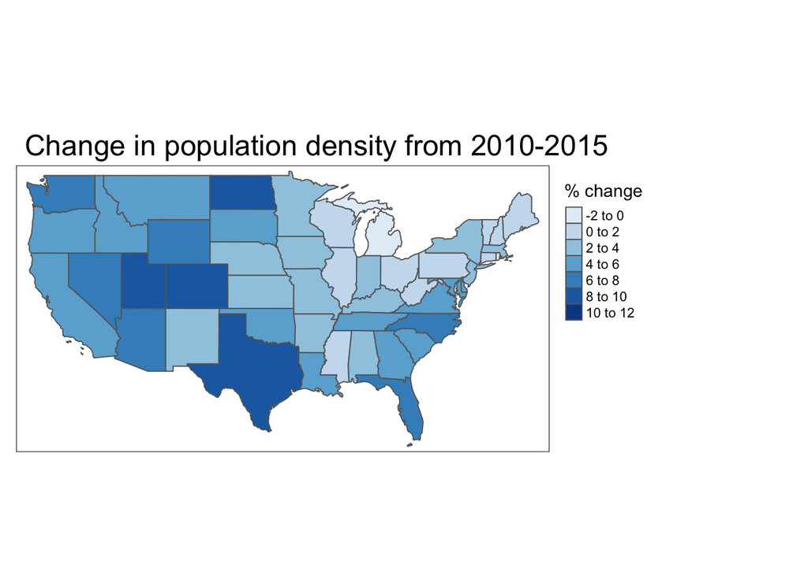

```r
#first, we'll calculate the population density in 2010 and 2015. Then we can subtract the population density in 2010 from 2015 to find the change
popchange <- states |>
  mutate(pop_dens_2010 = as.numeric(total_pop_10 / AREA),
         pop_dens_2015 = as.numeric(total_pop_15 / AREA),
         percent_change = (100 * (pop_dens_2015 - pop_dens_2010)) / abs(pop_dens_2010))


#Now, lets plot it

tm_shape(popchange) +
  tm_polygons(col = 'percent_change',
              title = '% change',
              palette = 'Blues',
              midpoint = NA) +
  tm_layout(legend.outside = TRUE,
            main.title = 'Change in population density from 2010-2015')
```

In how many states did population density decrease? (3)

```r
#Which states did population decerase in?
dec_popchange <- popchange |>
  filter(percent_change < 0)

nrow(dec_popchange)
```

```
## [1] 2
```

```r
print('Only 2 - Michigan and Rhode Island')
```

```
## [1] "Only 2 - Michigan and Rhode Island"
```

## question 4

##### 10 points

How many of New Zealand’s high points are in the Canterbury region? (5)

```r
print('70 of the 101 highest points are in the Canterbury region')
```

```
## [1] "70 of the 101 highest points are in the Canterbury region"
```

```r
#We want to find how many of these red dots are in the canterbury region
tm_shape(nz) +
  tm_polygons(col = 'Name') +
  tm_shape(nz_height) +
  tm_dots(col = 'red')
```

```
## Some legend labels were too wide. These labels have been resized to 0.64. Increase legend.width (argument of tm_layout) to make the legend wider and therefore the labels larger.
```

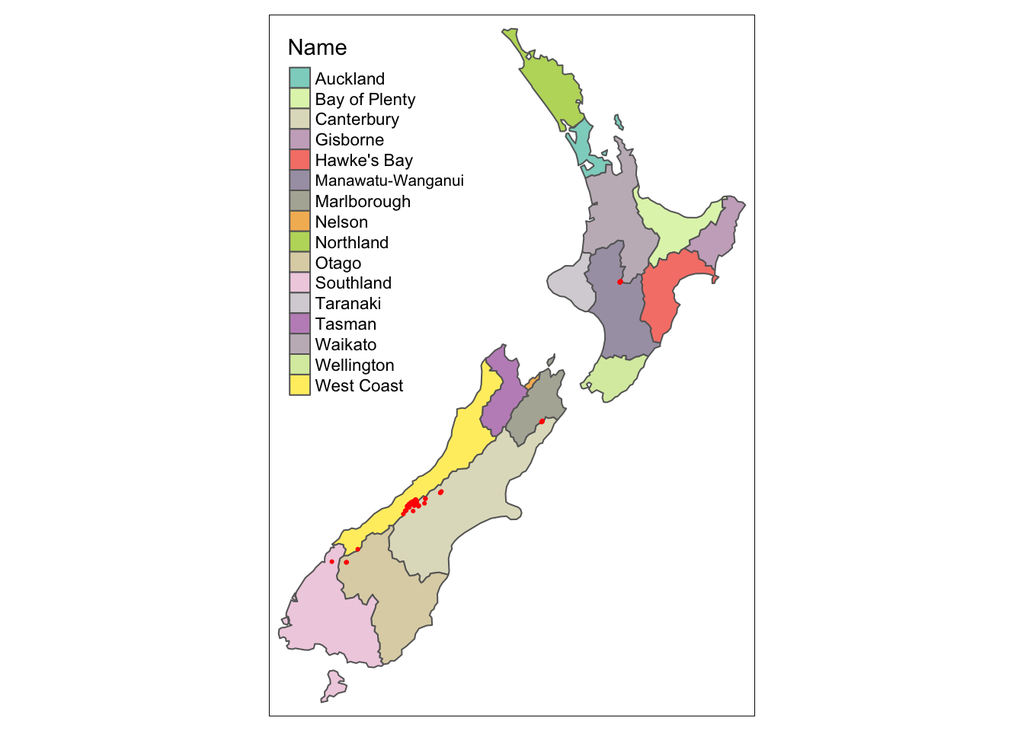

```r
#first, lets select the canterbury region:
canterbury <- nz |>
  filter(Name == 'Canterbury') #select canterbury
c_height <- nz_height |>
  st_filter(y = canterbury,
             .predicate = st_intersects)
#We can now check which points of nz_height intersect with canterbury
nrow(c_height)
```

```
## [1] 70
```

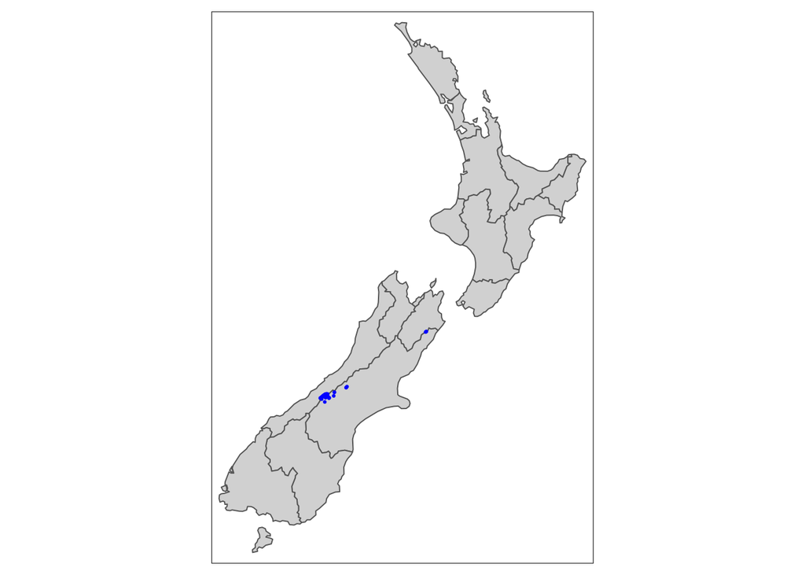

```r
#shape the region to the map of NZ in case we want a map
tm_shape(nz) +
  tm_polygons() +
  tm_shape(c_height) +
  tm_dots(col = 'blue')
```

Which region has the second highest number of “nz_height” points? And how many does it have? (5)

```r
#Using a join
height_join <- st_join(nz, nz_height) |>
  group_by(Name) |>
  summarise(n()) |>
  rename(n = 'n()') |>
  arrange(desc(n)) |>
  print()
```

```
## Simple feature collection with 16 features and 2 fields
## Geometry type: MULTIPOLYGON
## Dimension:     XY
## Bounding box:  xmin: 1090144 ymin: 4748537 xmax: 2089533 ymax: 6191874
## Projected CRS: NZGD2000 / New Zealand Transverse Mercator 2000
## # A tibble: 16 × 3
##    Name                  n                                                  geom
##    <chr>             <int>                                    <MULTIPOLYGON [m]>
##  1 Canterbury           70 (((1686902 5353233, 1679996 5344809, 1673699 5328829…
##  2 West Coast           22 (((1557042 5319333, 1554239 5309440, 1546356 5306561…
##  3 Waikato               3 (((1860345 5859665, 1857808 5853929, 1850511 5849040…
##  4 Manawatu-Wanganui     2 (((1866732 5664323, 1868949 5654440, 1865829 5649938…
##  5 Otago                 2 (((1335205 5126878, 1336956 5118634, 1325903 5102723…
##  6 Auckland              1 (((1803822 5900006, 1791443 5900571, 1790082 5883500…
##  7 Bay of Plenty         1 (((2049387 5832785, 2051016 5826423, 2040276 5825884…
##  8 Gisborne              1 (((2024489 5674920, 2019037 5677334, 2016277 5683982…
##  9 Hawke's Bay           1 (((2024489 5674920, 2024126 5663676, 2032576 5659653…
## 10 Marlborough           1 (((1686902 5353233, 1679241 5359478, 1667754 5357340…
## 11 Nelson                1 (((1624866 5417556, 1616643 5424521, 1618569 5428691…
## 12 Northland             1 (((1745493 6001802, 1740539 5995066, 1733165 5989714…
## 13 Southland             1 (((1229078 5062352, 1221427 5056736, 1217551 5038521…
## 14 Taranaki              1 (((1740438 5714538, 1743867 5711520, 1755759 5711464…
## 15 Tasman                1 (((1616643 5424521, 1624866 5417556, 1620946 5409416…
## 16 Wellington            1 (((1881590 5489434, 1875693 5479987, 1871588 5466618…
```

```r
print('West Coast - It has 22')
```

```
## [1] "West Coast - It has 22"
```

## question 5

##### 15 points

Create a new object representing all of the states the geographically intersect with Colorado.(5)  
Hint: use the “united_states” dataset. The most concise way to do this is with the subsetting method “[”.  
Make a map of the resulting states. (2.5)

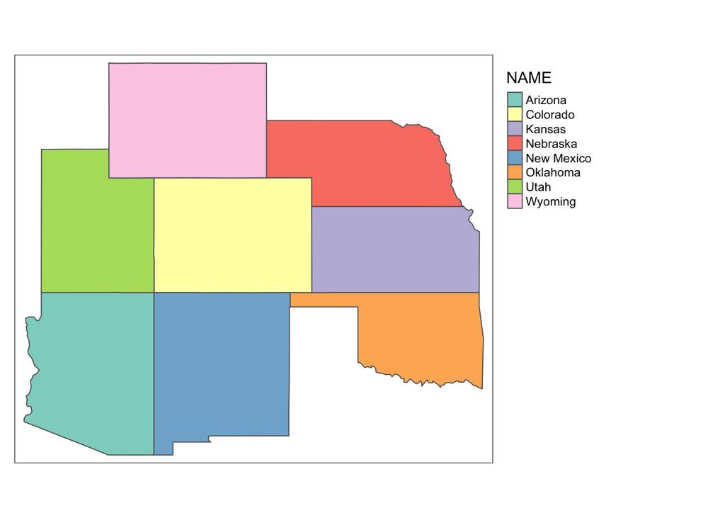

```r
#Filtering for Colorado
colorado <-  us_states |>
  filter(NAME == 'Colorado')

#using a filter to go through the us_states dataset and select the states that intersect colorado
intersecting_states <- us_states |>
  st_filter(y = colorado, .predicate = st_intersects)

#Mapping it!
tm_shape(intersecting_states) +
  tm_polygons(col = 'NAME') +
  tm_layout(legend.outside = TRUE)
```

Create another object representing all the objects that touch (have a shared boundary with) Colorado and plot the result.(5)  
Hint: remember you can use the argument op = st_intersects and other spatial relations during spatial subsetting operations in base R).  
Make a map of the resulting states. (2.5)

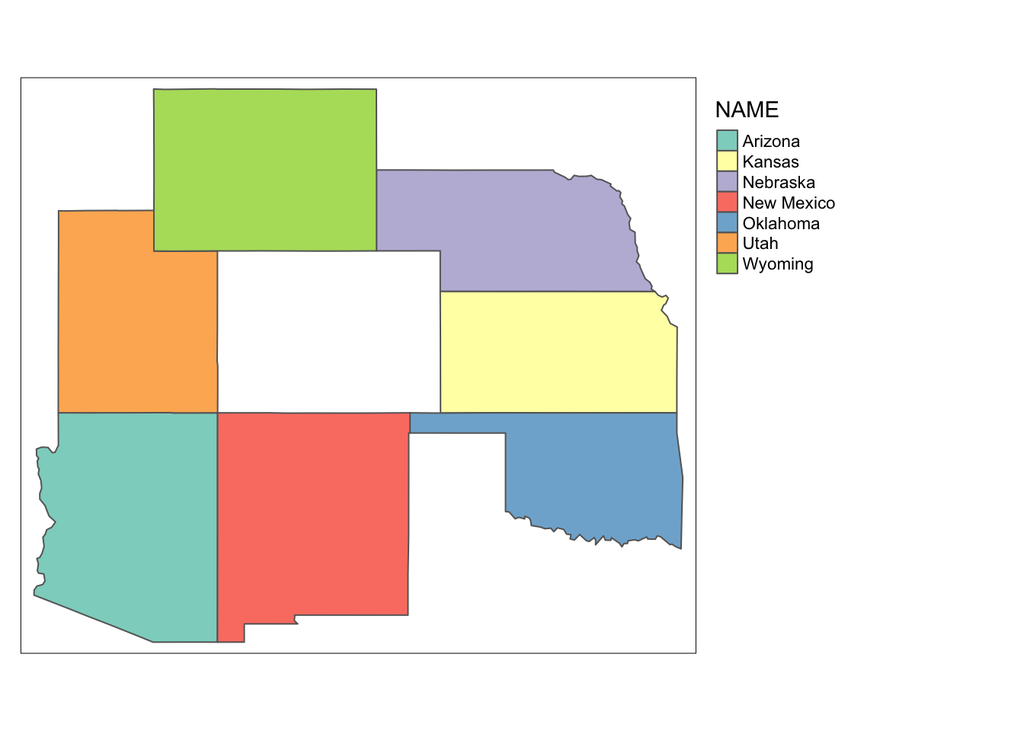

```r
touching_states <- us_states[colorado, op = st_touches]
tm_shape(touching_states) +
  tm_polygons(col = 'NAME') +
  tm_layout(legend.outside = TRUE)
```

## question 6

##### 10 points

Generate simplified versions of the “nz” dataset. Experiment with different values of keep (ranging from 0.5 to 0.00005) for **ms_simplify()** and dTolerance (from 100 to 100,000) **st_simplify()**. (5)

Map the results to show how the simplification changes as you change values.(5)

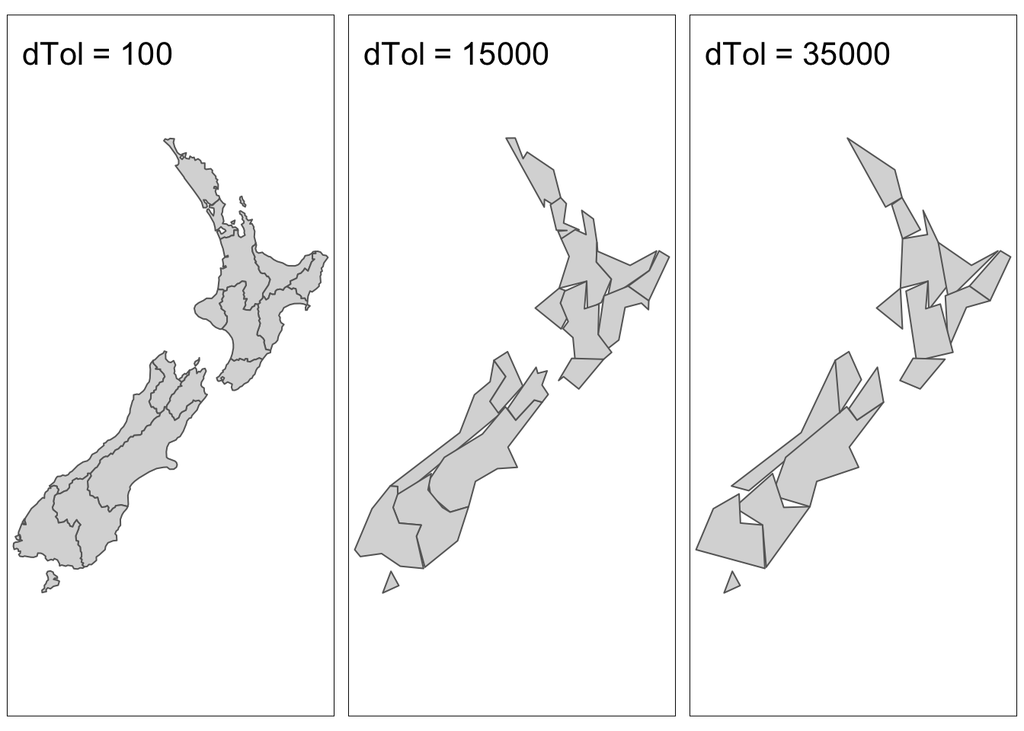

```r
#Using st_simplify
nz_simple_100 <-  nz |>
  st_simplify(dTolerance = 100)
g1 <- tm_shape(nz_simple_100) +
  tm_polygons() +
  tm_layout(title = 'dTol = 100')

nz_simple_1500 <- nz |>
  st_simplify(dTolerance = 15000)
g2 <- tm_shape(nz_simple_1500) +
  tm_polygons() +
  tm_layout(title = 'dTol = 15000')

nz_simple_3500 <- nz |>
  st_simplify(dTolerance = 35000)
g3 <- tm_shape(nz_simple_3500) +
  tm_polygons() +
  tm_layout(title = 'dTol = 35000')

#Using ms_simplify
k1 <- nz |>
  ms_simplify(keep = 0.5)
nz_simplek1 <-
  tm_shape(k1) +
  tm_polygons() +
  tm_layout(title = 'keep = 0.5')
k2 <- nz |>
  ms_simplify(keep = 0.05)
nz_simplek2 <-
  tm_shape(k2) +
  tm_polygons() +
  tm_layout(title = 'keep = 0.05')
k3 <-  nz |>
  ms_simplify(keep = 0.005)
nz_simplek3 <-
  tm_shape(k3) +
  tm_polygons() +
  tm_layout(title = 'keep = 0.005')

#Boundaries clearly get less well-defined as we increase dTol
tmap_arrange(g1, g2, g3)
```

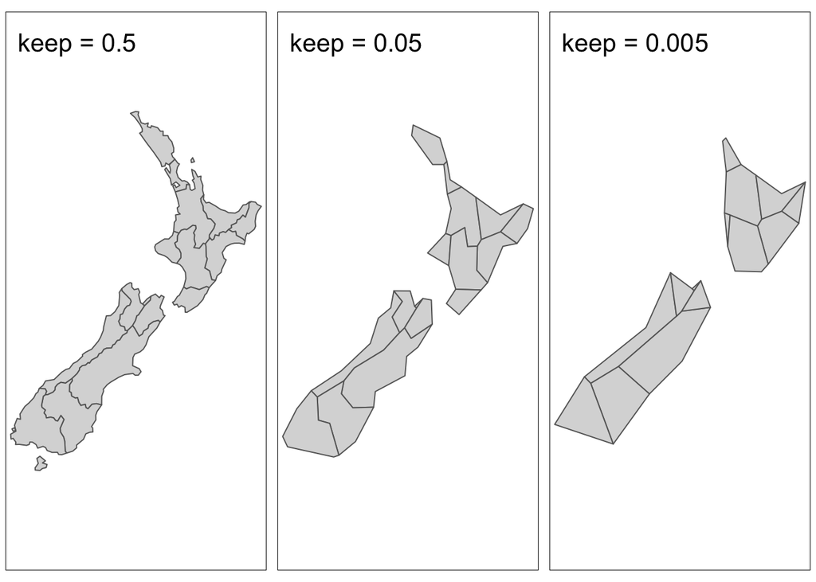

```r
tmap_arrange(nz_simplek1, nz_simplek2, nz_simplek3)
```

## question 7

##### 10 points

How many points from the “nz_height” dataset are within 100km of the Canterbury region?

```r
#creating a buffer zone
buffer <- st_buffer(canterbury, 100000)

#filtering which points in nz height are in the buffer zone
buffer_cant <- nz_height[buffer, ]
nrow(buffer_cant)
```

```
## [1] 95
```

```r
print('95 of the highest points are within 100km of the Canterbury region')
```

```
## [1] "95 of the highest points are within 100km of the Canterbury region"
```

## question 8

##### 15 points

Find the geographic centroid of the country of New Zealand. How far is it from the geographic centroid of Canterbury?

```r
#centroid for canterbury
cent_cant <- st_centroid(canterbury)
#centroid of nz, use union
cent_nz <- st_centroid(st_union(nz))

st_distance(cent_cant, cent_nz)
```

```
## Units: [m]
##          [,1]
## [1,] 234192.6
```

```r
print('234192m or 234.192 km')
```

```
## [1] "234192m or 234.192 km"
```